# ITEC 621 - Homework 2 -

Zach Maddigan

02,06,2019

*Note: save this file with the name HW1_YourLastName.Rmd [or HW2, etc.) and complete your homework in it.*

Note: this is a template for HW1, but you should use a similar template for HW2, 3 and 4, and also for your final project. Treat this homework and your project as a report. Format it and present it in a way that is attractive, easy to follow and businesslike. All your work should be labeled, numbered (if appropriate) and introduced. Overall, you should follow a format like this:

```r
#load data and packages:
library(car)
library(ggplot2)
library(GGally)
data("Salaries")
```

**1.1 Prepare and display a histogram for the response variable of interest: salary** Explanation or narrative

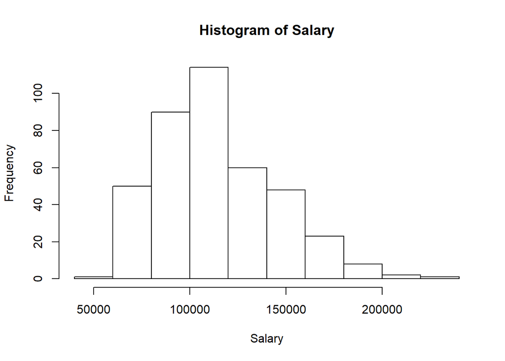

```r
# histogram of salares
hist(Salaries$salary, xlab = "Salary", main ="Histogram of Salary")
```

**1.2 Prepare a qqplot with a qqline line for salary**

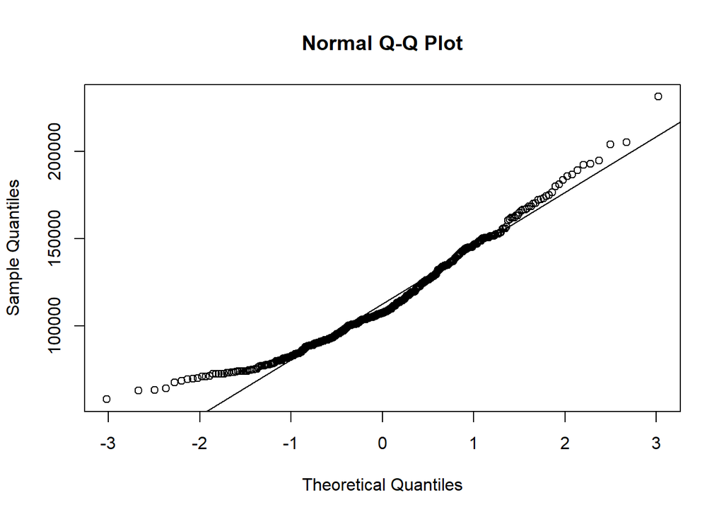

```r
qqnorm(Salaries$salary)
qqline(Salaries$salary)
```

**1.3 Answer briefly: based on your review of the data, is salary somewhat normally distributed? Why or why not?**

```r
#I would say based off the histogram the data has a slight skew to the right -
```

**1.4 Using the ggpairs(){GGally} function, display a correlation chart with all variables**

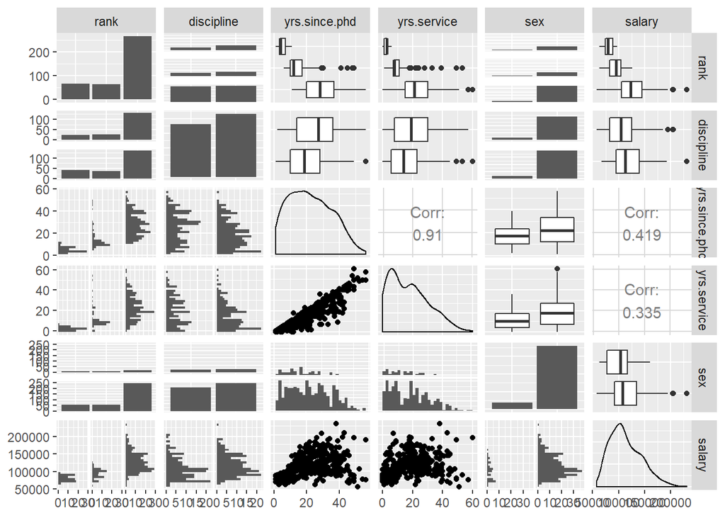

```r
ggpairs(Salaries)
```

**1.5 Answer briefly: based on your review of the data, does it appear to be a salary gender gap? Why or why not?**

[figure not shown]

```r
#creating boxplot for better view
boxplot(Salaries$sex, Salaries$salary)
```